# BE/BAT 485/585<

## Danielle Tadych

- Make sure you write your name and identify yourself on your work
- Your answers need to be in a single JupyterLab or Jupyter Notebook file/project
- Turn 2 copies: the executed code/notebook (*. ipynb) and an (html or PDF) exported copy (that has the answers + code).
- Show and annotate all necessary steps
- No group work please, just do your best
- You should have no issues turning in a perfect exam

### Multiple Choice Questions [15]

1. [3] Scattering causes the atmosphere to have its own brightness which helps illuminate objects in the shadow </br> **A. True** B. False
2. [3] If the speed of light (c) is 3 x 10^8 m/s what is the wavelength of radiation for a frequency = 500,000 x 10^9 Hz (cycles per seconds): </br> A. 16 x 10-5 m </br> **B. 6 x 10-7 m**</br> C. 1.6 x 10-5 m </br> D. 0.6 x 10-7 m

```python
c = 3e8
freq = 500000e9
wavelength = c/freq
print(wavelength, 'm')
print(wavelength*1e9,'nm')
```

```
6e-07 m
600.0 nm
```

1. [3] What is the approximate color of this wavelength? **Orange**
2. [3] Read the question carefully </br> Which of the following statement(s) is/are an **INCORRECT** explanation of why most remote sensing systems avoid detecting and recording wavelengths in the ultraviolet and blue portions of the spectrum.</br> A. detecting and recording the ultraviolet and blue wavelengths of radiation is difficult because of scattering and absorption in the atmosphere. </br> B. ozone gas in the upper atmosphere absorbs most of the ultraviolet radiation of wavelengths shorter than about 0.25 mm.</br> **C. after scattering the greater portion of the ultraviolet and blue wavelengths energy reaches and interacts with the Earth's surface** </br> D. Rayleigh scattering affects the shorter wavelengths more severely than longer wavelengths causing the remaining UV radiation and the shorter visible wavelengths to be scattered much more than longer wavelengths
3. [3] Pick all **correct** answers: </br> The ideal atmospheric conditions for remote sensing in the visible portion of the spectrum are at Noon on a Sunny, Dry day with no Clouds and no Pollution?</br> A. Dry, pollutant-free conditions would maximize the scattering and absorption that would take place due to water droplets and other particles in the atmosphere. </br> B. Cloud-free conditions guarantee that there will be uniform illumination </br> **C. Cloud-free conditions ensure there will be no shadows from clouds.** </br> **D. At noon the sun would be at its most directly overhead point thus reducing the distance radiation has to travel and therefore the effects of scattering to a minimum.**

### Multiple Choice Questions [15]

1. [3] What is the Maximum value of the digital number (DN) when the radiometric resolution is 12 bits?

```python
bits = 12
DN = 2**bits
print('Max Radiometric Res: ',DN,'(0 -',DN-1,')')
```

```
Max Radiometric Res:  4096 (0 - 4095 )
```

1. [3] What is the wavelength of maximum emission of a blackbody with temperature = 20oC?

```python
k = 2897 #micrometers * K
T = 20 #deg C
Kelv = 20 + 273.15
wav = k/Kelv
print("Maximum wavelength: ", wav, "micrometers")
```

```
Maximum wavelength:  9.882312809142078 micrometers
```

1. [3] If a distant star emission peaks at a wavelength = 0.25 microm, compute its surface temperature?

```python
wav = 0.25 # micrometers
T = k/wav
degC = T-273.15
print("Maximum temperature is ", degC, " degrees celsius or ", T, "Kelvins.")
```

```
Maximum temperature is  11314.85  degrees celsius or  11588.0 Kelvins.
```

1. [3] What is the difference between Irradiance and Radiance? </br> **Radiance is the amount of power transmitted, reflected, or emitted by a surface measured in unit power per solid angle per unit projected area, whereas irradiance is the light recieved from a light source. So in other words, radiance would be the power from the sun but irradiance is what we would measure on earth, which decreases with distance.**
2. *Eta Carinae* is a blue hypergiant star, located about 7,500 light-years from the Sun. Its temperature is 66,500 degF, and it is probably one of the hottest stars in the Universe.  
   Assume:
- σ (the Stefan-Boltzmann constant) = 5.7×10-8 W/m^2xK^4 and
- Wien’s displacement constant, k = 2897 µm. K  
  A. [5] Compute its emissive power (M) and peak emission wavelength (lambda)

```python
import math as math

T = 66500 # degF
sigma = 5.7e-8 # W/m2K4
k = 2897 # micrometers * K

# T_Sun temperature in Kelvin
# Kelvin = (Fahrenheit - 32) / 1.8 + 273.15
T = (T-32)/1.8 + 273.15 # In degree Kelvin

# Sun Emmissivity
Ms = sigma * math.pow(T,4)

print("The sun's radiation @ Temperature  = ",T, "K")
#print("Temperature = ",T, "K")
print("Emissive Power M (Watts/m^2)= ", Ms, "or = M (MW/m^2)",Ms/1E6)
wav = k/T
print("Maximum wavelength: ", wav, "micrometers")
```

[output not shown]

```
B. [5] Can you compute how much ‘insolation’ hits the Earth at the Equator (at the spring equinox) at local noon if this was our sun (same size and distance of our actual sun)?
```

```python
# Let us now use the databse of astrophysics constants
# From https://het.as.utexas.edu/HET/Software/Astropy-1.0/constants/index.html
from astropy import constants as const
import numpy as np

Rs=const.R_sun
Re=const.R_earth

# Distance Sun to Earth 149597870700 m ~ 149.6E9
Dse=149.6E9

print ("The Sun Radius = ", Rs)
print ("The Earth Radius = ", Re)
print ("Sun Earth Distance = ", Dse)

# so at the Earth Surface the irradiance received is
I =  Ms * (Rs*Rs)/(Dse*Dse)

print("Irradiance at Earth Surface:")
print("Irradiance (W/m^2)=",I,"and in (J/s.m^2)=",I)
#print("Irradiance (J/s.m^2)=",I)

# Now for Tucson during the spring equinox
lat = 0
tilt = 2
x = lat + tilt
# conversion between degrees and degree Radians for all the whole array [x] created above
x_rad=math.pi*x/180

print("Irradiance at Equator:")
print("Irradiance (W/m^2)=",I*np.cos(x_rad),"and in (J/s.m^2)=",I*np.cos(x_rad))
#print("Irradiance (J/s.m^2)=",I)
```

```
The Sun Radius =    Name   = Nominal solar radius
  Value  = 695700000.0
  Uncertainty  = 0.0
  Unit  = m
  Reference = IAU 2015 Resolution B 3
The Earth Radius =    Name   = Nominal Earth equatorial radius
  Value  = 6378100.0
  Uncertainty  = 0.0
  Unit  = m
  Reference = IAU 2015 Resolution B 3
Sun Earth Distance =  149600000000.0
Irradiance at Earth Surface:
Irradiance (W/m^2)= 2360580.8165674414 m2 and in (J/s.m^2)= 2360580.8165674414 m2
Irradiance at Equator:
Irradiance (W/m^2)= 2359142.814514748 m2 and in (J/s.m^2)= 2359142.814514748 m2
```

1. [3] Derive the COSINE law and explain its value to EMR energy interaction?

The Lambert's cosine law states that the radiant intensity is directly proportional to the cosine of the angle θ between the direction of the incident light and the surface normal. As the angle of incidence changes from 90$^o$ (normal angle) the less effective the transmission. This leads to the simple equation that says:

#### E<sub>θ</sub> = E. cos(θ) **[Eq. 3]**

[figure not shown]

1. The figure on the midterm shows how Landsat maps the Earth and collects data. Scan width, swath width, spatial resolution, and satellite altitude are all shown in the figure. Answer the following questions:  
   a. [2] What is the scanning configuration of the system?  
   **Across Track Scanner**  
   b. [2] What is the type of orbit of the satellite?  
   **Polar orbit**  
   c. [3] How many pixels each scan line has?  
   **Since this is polar orbiting sattelite, assuming scanline would be one rotation around the earth, there would be about 1,335,833 pixels. Note this is assuming no changes from elevation.**  
   d. [3] If the satellite moves at a speed of about 7 km/s, how many scans will be in each second?  
   **0.000174 scans/second**

```python
# the circumference of the earth is 40,075km
ground_res = 30 # meters
circ = 40075 * 1000 # meters
pixel_num = circ/ground_res
print('Pixel Number in one scan: ',pixel_num)
print()

# Scans/second
v = 7 * 1000 # m/s
scan = 1/circ #scan/m
scan_sec = scan*v
print("Number of scans per second: ",scan_sec)
```

```
Pixel Number in one scan:  1335833.3333333333

Number of scans per second:  0.00017467248908296942
```

### Answer with annotated, clean, and nicely designed Python book [50]

1. Load the BSQ NEON image from D2L<NEON_ExamData.bsq> (all 426 bands). Additional ancillary and supporting files are in the same Exam directory in particular the wavelength metadata file

   a. [5] Create and label (at least title identifying the location, but more is better) Grayscale images from the Blue, Green, Red, NIR, SWIR-1*, SWIR-2*

   NOTE: SWIR-1 and SWIR-2 are as defined for Landsat OLI (consult Lab-4).

```python
# load library modules
import os
import numpy as np
import matplotlib.pyplot as plt

#Notice this is a new library with additonal functionality
import viplab_lib2 as vip

# Starts main program
#subset file information
filename="NEON_ExamData.bsq"
nrows=500
ncols=500
nbands=426
datatype=np.int16

# Read all bands into a single 3D DataCube

# Notice the -426  in the call and that means load all bands (all 426 of them)

DataCube=vip.BSQ_band_read(filename,-426,nrows,ncols)

# Assign some of the bands to band/color names that are easier to remember instaead of listing numbers
# Remember these could be from any neighboring bands also since this is hyperspectral
bandRED=48
bandGREEN=34
bandBLUE=17
bandNIR=97

# The clue here from the exam is a little confusing so I'm going to assume the bands for SWIR1 and SWIR2
# are 5 and 6 (indexing starts at zero though so 4 and 5) because that's what it was for landsat
bandSWIR1 = 4
bandSWIR2 = 5
```

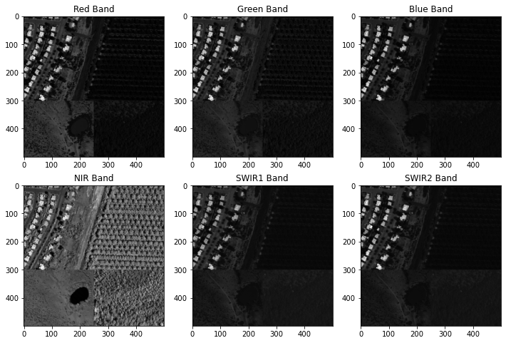

```python
fig, ax = plt.subplots(2, 3,figsize=(12,8)) # a plot with 2 areas labeled 1 and 2 , indexed below 0 and 1

ax[0, 0].imshow(DataCube[:,:,bandRED],cmap='gray');
ax[0, 0].title.set_text('Red Band')

ax[0, 1].imshow(DataCube[:,:,bandGREEN],cmap='gray');
ax[0, 1].title.set_text('Green Band')

ax[0, 2].imshow(DataCube[:,:,bandBLUE],cmap='gray');
ax[0, 2].title.set_text('Blue Band')

ax[1, 0].imshow(DataCube[:,:,bandNIR],cmap='gray');
ax[1, 0].title.set_text('NIR Band')

ax[1, 1].imshow(DataCube[:,:,bandSWIR1],cmap='gray');
ax[1, 1].title.set_text('SWIR1 Band')

ax[1, 2].imshow(DataCube[:,:,bandSWIR2],cmap='gray');
ax[1, 2].title.set_text('SWIR2 Band')
```

b. [5] Now, apply a reasonable colorbar/scale to each of these grayscale images

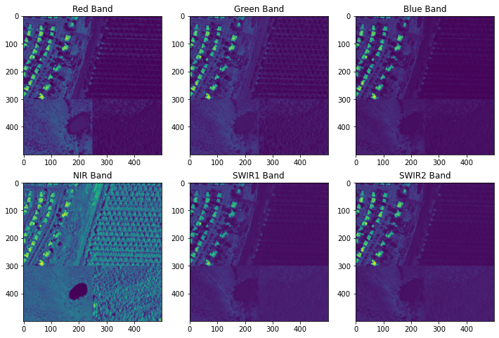

```python
fig, ax = plt.subplots(2, 3,figsize=(12,8)) # a plot with 2 areas labeled 1 and 2 , indexed below 0 and 1

ax[0, 0].imshow(DataCube[:,:,bandRED],cmap='viridis');
ax[0, 0].title.set_text('Red Band')

ax[0, 1].imshow(DataCube[:,:,bandGREEN],cmap='viridis');
ax[0, 1].title.set_text('Green Band')

ax[0, 2].imshow(DataCube[:,:,bandBLUE],cmap='viridis');
ax[0, 2].title.set_text('Blue Band')

ax[1, 0].imshow(DataCube[:,:,bandNIR],cmap='viridis');
ax[1, 0].title.set_text('NIR Band')

ax[1, 1].imshow(DataCube[:,:,bandSWIR1],cmap='viridis');
ax[1, 1].title.set_text('SWIR1 Band')

ax[1, 2].imshow(DataCube[:,:,bandSWIR2],cmap='viridis');
ax[1, 2].title.set_text('SWIR2 Band')
```

c. [5] Create a true color RGB (you will need to pick which bands to assign to the RGB planes), Create a [SWIR-NIR-Red] and [NIR-Red-Green] False Color Composite images.

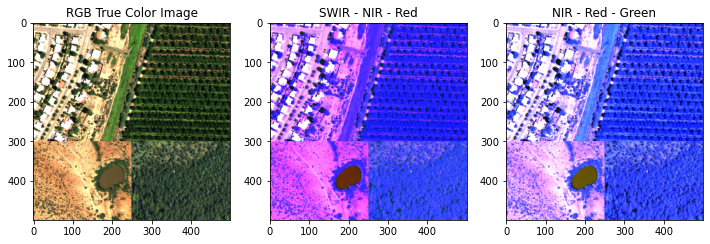

```python
DataRed = DataCube[:,:,bandRED]
DataGreen = DataCube[:,:,bandGREEN]
DataBlue = DataCube[:,:,bandBLUE]
DataNIR = DataCube[:,:,bandNIR]
DataSWIR1 = DataCube[:,:,bandSWIR1]
DataSWIR2 = DataCube[:,:,bandSWIR2]

RGBImage=vip.Image_getRGB(DataRed,DataGreen,DataBlue,5000)
SWIRNR = vip.Image_getRGB(DataRed,DataSWIR2,DataNIR,5000)
NRG = vip.Image_getRGB(DataRed,DataGreen,DataNIR,5000)

fig, ax = plt.subplots(1, 3,figsize=(12,8)) # a plot with 2 areas labeled 1 and 2 , indexed below 0 and 1

ax[0].imshow(RGBImage);
ax[0].title.set_text('RGB True Color Image')

ax[1].imshow(SWIRNR);
ax[1].title.set_text('SWIR - NIR - Red')

ax[2].imshow(NRG);
ax[2].title.set_text('NIR - Red - Green')
```

e. [5] Which band combination would you use to study vegetation? Why? !  
**Probably SWIR - NIR - Green because it would be easy to distinguish between different active vegetation. However, if I was really trying to determine active vegetation, I would probably calculate NDVI and plot that with a greens color map**

1. [10] Extract, plot, and label the spectral signatures for a Pine Tree, Pecan Tree, Patch of Green Grass, Bare Soil, Dry Grass, Road, Water tank, Roof/House

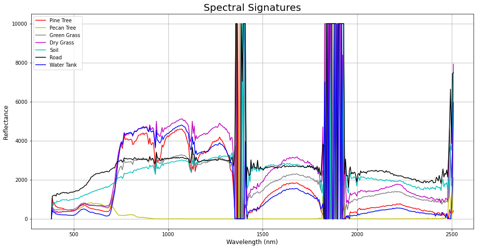

```python
# Read the wavelength values from the textfile
file = open(r'NEON_wavelength_values.txt', 'r')
Xvalues= file.readlines()
nvalues=len(Xvalues)

#convert text to number (float)
for i in range(0,nvalues):
  Xvalues[i]=float(Xvalues[i])

# close text file
file.close

# Extract a single pixel through all bands now to develop a spectral signature
PineTree_Spectra=DataCube[400,400,:]
PecanTree_Spectra=DataCube[400,200,:]
GreenGrass_Spectra=DataCube[220,200,:]
DryGrass_Spectra = DataCube[10,490,:]
Soil_Spectra = DataCube[210,40,:]
Road_Spectra=DataCube[47,16,:]
WaterTank_Spectra=DataCube[200,400,:]

plt.figure(figsize=(16,8))
plt.title('Spectral Signatures',fontsize=20)
plt.xlabel('Wavelength (nm)',fontsize=12)
plt.ylabel('Reflectance ',fontsize=12)
plt.plot(Xvalues,PineTree_Spectra,color='r',label='Pine Tree')
plt.plot(Xvalues,PecanTree_Spectra,color='y',label='Pecan Tree')
plt.plot(Xvalues,GreenGrass_Spectra,color='grey',label='Green Grass')
plt.plot(Xvalues,DryGrass_Spectra,color='m',label='Dry Grass')
plt.plot(Xvalues,Soil_Spectra,color='c',label='Soil')
plt.plot(Xvalues,Road_Spectra,color='k',label='Road')
plt.plot(Xvalues,WaterTank_Spectra,color='b',label='Water Tank')
plt.grid()
plt.legend(loc='upper left')
```

1. [10] Add labels (circle or other shapes and annotate the image properly) to indicate the locations of you extracted the spectral signatures and what is there.

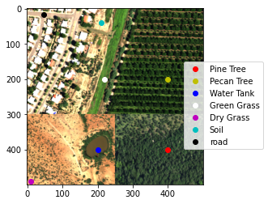

```python
plt.figure()
plt.imshow(RGBImage)
plt.plot(400,400,'ro',label='Pine Tree')
plt.plot(400,200,'yo',label='Pecan Tree')
plt.plot(200,400,'bo',label='Water Tank')
plt.plot(220,200,'wo',label='Green Grass')
plt.plot(10,490,'mo',label='Dry Grass')
plt.plot(210,40,'co',label='Soil')
plt.plot(47,16,'ko',label='road')
plt.legend(loc = (0.89, 0.2))
```

### Bonus questions, and please try them all

1. [5] Create a new image [2-D NumPy Array] and fill it with data following this NDVI equation:  
   NDVI= ((NIR-Red))/((NIR+Red) )  
   You will need to decide which of the bands to use for NIR and Red
- Make sure you do not divide by ZERO, so you will need an exception handler (logic in your code to skip division by ZERO). It would be great if you could design a separate user defined function that you would call.  
  a. Plot this image and use the ‘YlGn’ or ‘Greens’ cmap colorbar/scale and add the color legend, labels, etc. to the image.  
  b. Scatterplot NDVI values for the objects from above (Q.13), Y = NDVI and X = Index or a Label of the point

```python
denom = DataNIR + DataRed

print(len(denom))
```

```
500
```

```python
for i in range(500):
    if denom[i].all() > 0:
        NDVI = ((DataNIR - DataRed)/(DataNIR + DataRed))
    else:
        NDVI = 0

print(NDVI)
print(type(NDVI))
# plt.plot(NDVI)
```

```
[[0.74876238 0.4587202  0.44248044 ... 0.75541796 0.60356653 0.89055794]
 [0.74876238 0.75866388 0.66102659 ... 0.82378223 0.82941176 0.82947977]
 [0.81567614 0.83237822 0.61530122 ... 0.84798712 0.80569948 0.8931083 ]
 ...
 [0.22892768 0.24246623 0.23627258 ... 0.84314325 0.83352833 0.81224726]
 [0.22540382 0.25420296 0.24101947 ... 0.83095809 0.79114303 0.76098689]
 [0.2345997  0.27350254 0.23730061 ... 0.83095781 0.81291173 0.73154362]]
<class 'numpy.ndarray'>
```

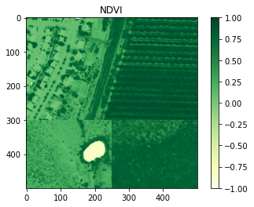

```python
plt.title('NDVI')
plt.imshow(NDVI, cmap = 'YlGn')
plt.colorbar()
```

```python
??np.array
```

[output not shown]

[output cut: 64 more lines]

[output not shown]

```python
Index = np.array([[range(500)],[range(500)]])
print(Index)
```

[output not shown]

[output cut: 46 more lines]

[figure not shown]

```python
Index = np.array((500,500))

# Create a ScatterPlot
plt.style.use('default')
plt.figure(figsize=(10,6))
plt.title('Scatter Plot')
plt.xlabel('Red')
plt.ylabel('NDVI')
plt.scatter(NDVI,DataRed,marker='o',alpha=0.5)
plt.grid()
```